# Risk Factor Analysis

## Outcome Variable

**Outcome Variable:** ever_stunted

## Predictor Variables

**Intervention Variable:** month

**Adjustment Set:**

unadjusted

## Stratifying Variables

The analysis was stratified on these variable(s):

- agecat
- studyid
- country

## Data Summary

| agecat | studyid | country | month | ever_stunted | n_cell | n |
| --- | --- | --- | --- | --- | --- | --- |
| 0-24 months (no birth st.) | ki0047075b-MAL-ED | BANGLADESH | 1 | 0 | 9 | 217 |
| 0-24 months (no birth st.) | ki0047075b-MAL-ED | BANGLADESH | 1 | 1 | 9 | 217 |
| 0-24 months (no birth st.) | ki0047075b-MAL-ED | BANGLADESH | 2 | 0 | 7 | 217 |
| 0-24 months (no birth st.) | ki0047075b-MAL-ED | BANGLADESH | 2 | 1 | 11 | 217 |
| 0-24 months (no birth st.) | ki0047075b-MAL-ED | BANGLADESH | 3 | 0 | 8 | 217 |
| 0-24 months (no birth st.) | ki0047075b-MAL-ED | BANGLADESH | 3 | 1 | 12 | 217 |
| 0-24 months (no birth st.) | ki0047075b-MAL-ED | BANGLADESH | 4 | 0 | 12 | 217 |
| 0-24 months (no birth st.) | ki0047075b-MAL-ED | BANGLADESH | 4 | 1 | 10 | 217 |
| 0-24 months (no birth st.) | ki0047075b-MAL-ED | BANGLADESH | 5 | 0 | 5 | 217 |
| 0-24 months (no birth st.) | ki0047075b-MAL-ED | BANGLADESH | 5 | 1 | 12 | 217 |
| 0-24 months (no birth st.) | ki0047075b-MAL-ED | BANGLADESH | 6 | 0 | 3 | 217 |
| 0-24 months (no birth st.) | ki0047075b-MAL-ED | BANGLADESH | 6 | 1 | 2 | 217 |
| 0-24 months (no birth st.) | ki0047075b-MAL-ED | BANGLADESH | 7 | 0 | 9 | 217 |
| 0-24 months (no birth st.) | ki0047075b-MAL-ED | BANGLADESH | 7 | 1 | 8 | 217 |
| 0-24 months (no birth st.) | ki0047075b-MAL-ED | BANGLADESH | 8 | 0 | 10 | 217 |
| 0-24 months (no birth st.) | ki0047075b-MAL-ED | BANGLADESH | 8 | 1 | 10 | 217 |
| 0-24 months (no birth st.) | ki0047075b-MAL-ED | BANGLADESH | 9 | 0 | 9 | 217 |
| 0-24 months (no birth st.) | ki0047075b-MAL-ED | BANGLADESH | 9 | 1 | 11 | 217 |
| 0-24 months (no birth st.) | ki0047075b-MAL-ED | BANGLADESH | 10 | 0 | 14 | 217 |
| 0-24 months (no birth st.) | ki0047075b-MAL-ED | BANGLADESH | 10 | 1 | 6 | 217 |
| 0-24 months (no birth st.) | ki0047075b-MAL-ED | BANGLADESH | 11 | 0 | 7 | 217 |
| 0-24 months (no birth st.) | ki0047075b-MAL-ED | BANGLADESH | 11 | 1 | 8 | 217 |
| 0-24 months (no birth st.) | ki0047075b-MAL-ED | BANGLADESH | 12 | 0 | 11 | 217 |
| 0-24 months (no birth st.) | ki0047075b-MAL-ED | BANGLADESH | 12 | 1 | 14 | 217 |
| 0-24 months (no birth st.) | ki0047075b-MAL-ED | BRAZIL | 1 | 0 | 11 | 208 |
| 0-24 months (no birth st.) | ki0047075b-MAL-ED | BRAZIL | 1 | 1 | 2 | 208 |
| 0-24 months (no birth st.) | ki0047075b-MAL-ED | BRAZIL | 2 | 0 | 18 | 208 |
| 0-24 months (no birth st.) | ki0047075b-MAL-ED | BRAZIL | 2 | 1 | 5 | 208 |
| 0-24 months (no birth st.) | ki0047075b-MAL-ED | BRAZIL | 3 | 0 | 18 | 208 |
| 0-24 months (no birth st.) | ki0047075b-MAL-ED | BRAZIL | 3 | 1 | 2 | 208 |

[output cut: 1962 more lines]

The following strata were considered:

- agecat: 0-24 months (no birth st.), studyid: ki0047075b-MAL-ED, country: BANGLADESH
- agecat: 0-24 months (no birth st.), studyid: ki0047075b-MAL-ED, country: BRAZIL
- agecat: 0-24 months (no birth st.), studyid: ki0047075b-MAL-ED, country: INDIA
- agecat: 0-24 months (no birth st.), studyid: ki0047075b-MAL-ED, country: NEPAL
- agecat: 0-24 months (no birth st.), studyid: ki0047075b-MAL-ED, country: PERU
- agecat: 0-24 months (no birth st.), studyid: ki0047075b-MAL-ED, country: SOUTH AFRICA
- agecat: 0-24 months (no birth st.), studyid: ki0047075b-MAL-ED, country: TANZANIA, UNITED REPUBLIC OF
- agecat: 0-24 months (no birth st.), studyid: ki1000108-CMC-V-BCS-2002, country: INDIA
- agecat: 0-24 months (no birth st.), studyid: ki1000108-IRC, country: INDIA
- agecat: 0-24 months (no birth st.), studyid: ki1000109-EE, country: PAKISTAN
- agecat: 0-24 months (no birth st.), studyid: ki1000109-ResPak, country: PAKISTAN
- agecat: 0-24 months (no birth st.), studyid: ki1000304b-SAS-CompFeed, country: INDIA
- agecat: 0-24 months (no birth st.), studyid: ki1000304b-SAS-FoodSuppl, country: INDIA
- agecat: 0-24 months (no birth st.), studyid: ki1017093-NIH-Birth, country: BANGLADESH
- agecat: 0-24 months (no birth st.), studyid: ki1066203-TanzaniaChild2, country: TANZANIA, UNITED REPUBLIC OF
- agecat: 0-24 months (no birth st.), studyid: ki1112895-Guatemala BSC, country: GUATEMALA
- agecat: 0-24 months (no birth st.), studyid: ki1112895-iLiNS-Zinc, country: BURKINA FASO
- agecat: 0-24 months (no birth st.), studyid: ki1113344-GMS-Nepal, country: NEPAL
- agecat: 0-24 months (no birth st.), studyid: ki1114097-CMIN, country: BANGLADESH
- agecat: 0-24 months (no birth st.), studyid: ki1114097-CMIN, country: BRAZIL
- agecat: 0-24 months (no birth st.), studyid: ki1114097-CMIN, country: GUINEA-BISSAU
- agecat: 0-24 months (no birth st.), studyid: ki1114097-CMIN, country: PERU
- agecat: 0-24 months (no birth st.), studyid: ki1114097-CONTENT, country: PERU
- agecat: 0-24 months (no birth st.), studyid: ki1119695-PROBIT, country: BELARUS
- agecat: 0-24 months (no birth st.), studyid: ki1126311-ZVITAMBO, country: ZIMBABWE
- agecat: 0-24 months (no birth st.), studyid: ki1148112-LCNI-5, country: MALAWI
- agecat: 0-24 months (no birth st.), studyid: kiGH5241-JiVitA-3, country: BANGLADESH
- agecat: 0-24 months (no birth st.), studyid: kiGH5241-JiVitA-4, country: BANGLADESH
- agecat: 0-6 months (no birth st.), studyid: ki0047075b-MAL-ED, country: BANGLADESH
- agecat: 0-6 months (no birth st.), studyid: ki0047075b-MAL-ED, country: BRAZIL
- agecat: 0-6 months (no birth st.), studyid: ki0047075b-MAL-ED, country: INDIA
- agecat: 0-6 months (no birth st.), studyid: ki0047075b-MAL-ED, country: NEPAL
- agecat: 0-6 months (no birth st.), studyid: ki0047075b-MAL-ED, country: PERU
- agecat: 0-6 months (no birth st.), studyid: ki0047075b-MAL-ED, country: SOUTH AFRICA
- agecat: 0-6 months (no birth st.), studyid: ki0047075b-MAL-ED, country: TANZANIA, UNITED REPUBLIC OF
- agecat: 0-6 months (no birth st.), studyid: ki1000108-CMC-V-BCS-2002, country: INDIA
- agecat: 0-6 months (no birth st.), studyid: ki1000108-IRC, country: INDIA
- agecat: 0-6 months (no birth st.), studyid: ki1000109-EE, country: PAKISTAN
- agecat: 0-6 months (no birth st.), studyid: ki1000109-ResPak, country: PAKISTAN
- agecat: 0-6 months (no birth st.), studyid: ki1000304b-SAS-CompFeed, country: INDIA
- agecat: 0-6 months (no birth st.), studyid: ki1000304b-SAS-FoodSuppl, country: INDIA
- agecat: 0-6 months (no birth st.), studyid: ki1017093-NIH-Birth, country: BANGLADESH
- agecat: 0-6 months (no birth st.), studyid: ki1066203-TanzaniaChild2, country: TANZANIA, UNITED REPUBLIC OF
- agecat: 0-6 months (no birth st.), studyid: ki1112895-Guatemala BSC, country: GUATEMALA
- agecat: 0-6 months (no birth st.), studyid: ki1113344-GMS-Nepal, country: NEPAL
- agecat: 0-6 months (no birth st.), studyid: ki1114097-CMIN, country: BANGLADESH
- agecat: 0-6 months (no birth st.), studyid: ki1114097-CMIN, country: BRAZIL
- agecat: 0-6 months (no birth st.), studyid: ki1114097-CMIN, country: GUINEA-BISSAU
- agecat: 0-6 months (no birth st.), studyid: ki1114097-CMIN, country: PERU
- agecat: 0-6 months (no birth st.), studyid: ki1114097-CONTENT, country: PERU
- agecat: 0-6 months (no birth st.), studyid: ki1119695-PROBIT, country: BELARUS
- agecat: 0-6 months (no birth st.), studyid: ki1126311-ZVITAMBO, country: ZIMBABWE
- agecat: 0-6 months (no birth st.), studyid: ki1148112-LCNI-5, country: MALAWI
- agecat: 0-6 months (no birth st.), studyid: kiGH5241-JiVitA-3, country: BANGLADESH
- agecat: 0-6 months (no birth st.), studyid: kiGH5241-JiVitA-4, country: BANGLADESH
- agecat: 6-24 months, studyid: ki0047075b-MAL-ED, country: BANGLADESH
- agecat: 6-24 months, studyid: ki0047075b-MAL-ED, country: BRAZIL
- agecat: 6-24 months, studyid: ki0047075b-MAL-ED, country: INDIA
- agecat: 6-24 months, studyid: ki0047075b-MAL-ED, country: NEPAL
- agecat: 6-24 months, studyid: ki0047075b-MAL-ED, country: PERU
- agecat: 6-24 months, studyid: ki0047075b-MAL-ED, country: SOUTH AFRICA
- agecat: 6-24 months, studyid: ki0047075b-MAL-ED, country: TANZANIA, UNITED REPUBLIC OF
- agecat: 6-24 months, studyid: ki1000108-CMC-V-BCS-2002, country: INDIA
- agecat: 6-24 months, studyid: ki1000108-IRC, country: INDIA
- agecat: 6-24 months, studyid: ki1000109-EE, country: PAKISTAN
- agecat: 6-24 months, studyid: ki1000109-ResPak, country: PAKISTAN
- agecat: 6-24 months, studyid: ki1000304b-SAS-CompFeed, country: INDIA
- agecat: 6-24 months, studyid: ki1000304b-SAS-FoodSuppl, country: INDIA
- agecat: 6-24 months, studyid: ki1017093-NIH-Birth, country: BANGLADESH
- agecat: 6-24 months, studyid: ki1066203-TanzaniaChild2, country: TANZANIA, UNITED REPUBLIC OF
- agecat: 6-24 months, studyid: ki1112895-Guatemala BSC, country: GUATEMALA
- agecat: 6-24 months, studyid: ki1112895-iLiNS-Zinc, country: BURKINA FASO
- agecat: 6-24 months, studyid: ki1113344-GMS-Nepal, country: NEPAL
- agecat: 6-24 months, studyid: ki1114097-CMIN, country: BANGLADESH
- agecat: 6-24 months, studyid: ki1114097-CMIN, country: BRAZIL
- agecat: 6-24 months, studyid: ki1114097-CMIN, country: GUINEA-BISSAU
- agecat: 6-24 months, studyid: ki1114097-CMIN, country: PERU
- agecat: 6-24 months, studyid: ki1114097-CONTENT, country: PERU
- agecat: 6-24 months, studyid: ki1119695-PROBIT, country: BELARUS
- agecat: 6-24 months, studyid: ki1126311-ZVITAMBO, country: ZIMBABWE
- agecat: 6-24 months, studyid: ki1148112-LCNI-5, country: MALAWI
- agecat: 6-24 months, studyid: kiGH5241-JiVitA-3, country: BANGLADESH
- agecat: 6-24 months, studyid: kiGH5241-JiVitA-4, country: BANGLADESH

### Dropped Strata

Some strata were dropped due to rare outcomes:

- agecat: 0-24 months (no birth st.), studyid: ki0047075b-MAL-ED, country: BANGLADESH
- agecat: 0-24 months (no birth st.), studyid: ki0047075b-MAL-ED, country: BRAZIL
- agecat: 0-24 months (no birth st.), studyid: ki0047075b-MAL-ED, country: INDIA
- agecat: 0-24 months (no birth st.), studyid: ki0047075b-MAL-ED, country: NEPAL
- agecat: 0-24 months (no birth st.), studyid: ki0047075b-MAL-ED, country: SOUTH AFRICA
- agecat: 0-24 months (no birth st.), studyid: ki0047075b-MAL-ED, country: TANZANIA, UNITED REPUBLIC OF
- agecat: 0-24 months (no birth st.), studyid: ki1000108-CMC-V-BCS-2002, country: INDIA
- agecat: 0-24 months (no birth st.), studyid: ki1000108-IRC, country: INDIA
- agecat: 0-24 months (no birth st.), studyid: ki1000109-EE, country: PAKISTAN
- agecat: 0-24 months (no birth st.), studyid: ki1000109-ResPak, country: PAKISTAN
- agecat: 0-24 months (no birth st.), studyid: ki1000304b-SAS-FoodSuppl, country: INDIA
- agecat: 0-24 months (no birth st.), studyid: ki1112895-Guatemala BSC, country: GUATEMALA
- agecat: 0-24 months (no birth st.), studyid: ki1113344-GMS-Nepal, country: NEPAL
- agecat: 0-24 months (no birth st.), studyid: ki1114097-CMIN, country: BANGLADESH
- agecat: 0-24 months (no birth st.), studyid: ki1114097-CMIN, country: BRAZIL
- agecat: 0-24 months (no birth st.), studyid: ki1114097-CONTENT, country: PERU
- agecat: 0-6 months (no birth st.), studyid: ki0047075b-MAL-ED, country: BANGLADESH
- agecat: 0-6 months (no birth st.), studyid: ki0047075b-MAL-ED, country: BRAZIL
- agecat: 0-6 months (no birth st.), studyid: ki0047075b-MAL-ED, country: INDIA
- agecat: 0-6 months (no birth st.), studyid: ki0047075b-MAL-ED, country: NEPAL
- agecat: 0-6 months (no birth st.), studyid: ki0047075b-MAL-ED, country: PERU
- agecat: 0-6 months (no birth st.), studyid: ki0047075b-MAL-ED, country: SOUTH AFRICA
- agecat: 0-6 months (no birth st.), studyid: ki0047075b-MAL-ED, country: TANZANIA, UNITED REPUBLIC OF
- agecat: 0-6 months (no birth st.), studyid: ki1000108-CMC-V-BCS-2002, country: INDIA
- agecat: 0-6 months (no birth st.), studyid: ki1000109-EE, country: PAKISTAN
- agecat: 0-6 months (no birth st.), studyid: ki1000109-ResPak, country: PAKISTAN
- agecat: 0-6 months (no birth st.), studyid: ki1000304b-SAS-FoodSuppl, country: INDIA
- agecat: 0-6 months (no birth st.), studyid: ki1112895-Guatemala BSC, country: GUATEMALA
- agecat: 0-6 months (no birth st.), studyid: ki1113344-GMS-Nepal, country: NEPAL
- agecat: 0-6 months (no birth st.), studyid: ki1114097-CMIN, country: BANGLADESH
- agecat: 0-6 months (no birth st.), studyid: ki1114097-CMIN, country: BRAZIL
- agecat: 0-6 months (no birth st.), studyid: ki1114097-CMIN, country: GUINEA-BISSAU
- agecat: 0-6 months (no birth st.), studyid: ki1114097-CMIN, country: PERU
- agecat: 0-6 months (no birth st.), studyid: ki1114097-CONTENT, country: PERU
- agecat: 0-6 months (no birth st.), studyid: ki1148112-LCNI-5, country: MALAWI
- agecat: 0-6 months (no birth st.), studyid: kiGH5241-JiVitA-4, country: BANGLADESH
- agecat: 6-24 months, studyid: ki0047075b-MAL-ED, country: BANGLADESH
- agecat: 6-24 months, studyid: ki0047075b-MAL-ED, country: BRAZIL
- agecat: 6-24 months, studyid: ki0047075b-MAL-ED, country: INDIA
- agecat: 6-24 months, studyid: ki0047075b-MAL-ED, country: NEPAL
- agecat: 6-24 months, studyid: ki0047075b-MAL-ED, country: PERU
- agecat: 6-24 months, studyid: ki0047075b-MAL-ED, country: SOUTH AFRICA
- agecat: 6-24 months, studyid: ki0047075b-MAL-ED, country: TANZANIA, UNITED REPUBLIC OF
- agecat: 6-24 months, studyid: ki1000108-CMC-V-BCS-2002, country: INDIA
- agecat: 6-24 months, studyid: ki1000108-IRC, country: INDIA
- agecat: 6-24 months, studyid: ki1000109-EE, country: PAKISTAN
- agecat: 6-24 months, studyid: ki1000109-ResPak, country: PAKISTAN
- agecat: 6-24 months, studyid: ki1000304b-SAS-FoodSuppl, country: INDIA
- agecat: 6-24 months, studyid: ki1112895-Guatemala BSC, country: GUATEMALA
- agecat: 6-24 months, studyid: ki1113344-GMS-Nepal, country: NEPAL
- agecat: 6-24 months, studyid: ki1114097-CMIN, country: BANGLADESH
- agecat: 6-24 months, studyid: ki1114097-CMIN, country: BRAZIL
- agecat: 6-24 months, studyid: ki1114097-CONTENT, country: PERU

## Methods Detail

We’re interested in the causal parameters $E[Y_a]$ for all values of $a \in \mathcal{A}$. These parameters represent the mean outcome if, possibly contrary to fact, we intervened to set all units to have $A=a$. Under the randomization and positivity assumptions, these are identified by the statistical parameters $\psi_a=E_W[E_{Y|A,W}(Y|A=a,W)]$. In addition, we’re interested in the mean of $Y$, $E[Y]$ under no intervention (the observed mean). We will estimate these parameters by using SuperLearner to fit the relevant likelihood factors – $E_{Y|A,W}(Y|A=a,W)$ and $p(A=a|W)$, and then updating our likelihood fit using a joint TMLE.

For unadjusted analyses ($W=\{\}$), initial likelihoods were estimated using Lrnr_glm to estimate the simple $E(Y|A)$ and Lrnr_mean to estimate $p(A)$. For adjusted analyses, a small library containing Lrnr_glmnet, Lrnr_xgboost, and Lrnr_mean was used.

Having estimated these parameters, we will then use the delta method to estimate relative risks and attributable risks relative to a prespecified baseline level of $A$.

# Results Detail

## Results Plots

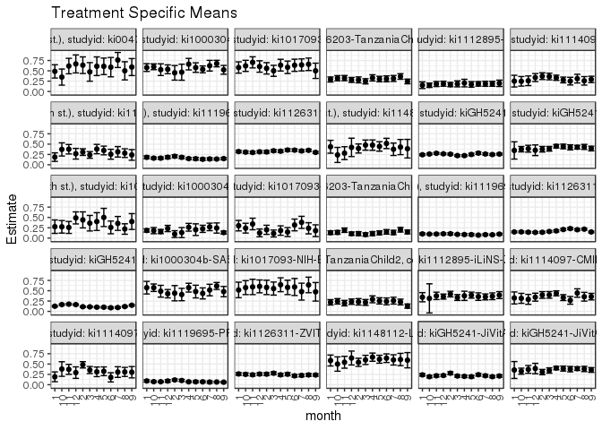

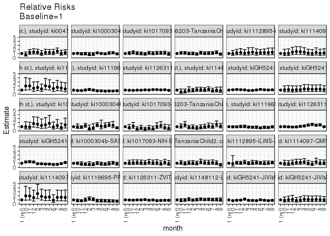

[figure not shown]

[figure not shown]

## Results Table

### Parameter: TSM

| agecat | studyid | country | intervention_level | baseline_level | estimate | ci_lower | ci_upper |
| --- | --- | --- | --- | --- | --- | --- | --- |
| 0-24 months (no birth st.) | ki0047075b-MAL-ED | PERU | 1 | NA | 0.4864865 | 0.3251337 | 0.6478393 |
| 0-24 months (no birth st.) | ki0047075b-MAL-ED | PERU | 2 | NA | 0.6363636 | 0.4349722 | 0.8377551 |
| 0-24 months (no birth st.) | ki0047075b-MAL-ED | PERU | 3 | NA | 0.4736842 | 0.2487493 | 0.6986191 |
| 0-24 months (no birth st.) | ki0047075b-MAL-ED | PERU | 4 | NA | 0.6111111 | 0.3854781 | 0.8367441 |
| 0-24 months (no birth st.) | ki0047075b-MAL-ED | PERU | 5 | NA | 0.6086957 | 0.4088662 | 0.8085251 |
| 0-24 months (no birth st.) | ki0047075b-MAL-ED | PERU | 6 | NA | 0.5882353 | 0.3538439 | 0.8226267 |
| 0-24 months (no birth st.) | ki0047075b-MAL-ED | PERU | 7 | NA | 0.7619048 | 0.5793967 | 0.9444128 |
| 0-24 months (no birth st.) | ki0047075b-MAL-ED | PERU | 8 | NA | 0.5000000 | 0.2804563 | 0.7195437 |
| 0-24 months (no birth st.) | ki0047075b-MAL-ED | PERU | 9 | NA | 0.5909091 | 0.3850714 | 0.7967468 |
| 0-24 months (no birth st.) | ki0047075b-MAL-ED | PERU | 10 | NA | 0.3478261 | 0.1528125 | 0.5428397 |
| 0-24 months (no birth st.) | ki0047075b-MAL-ED | PERU | 11 | NA | 0.6153846 | 0.4280293 | 0.8027399 |
| 0-24 months (no birth st.) | ki0047075b-MAL-ED | PERU | 12 | NA | 0.6666667 | 0.4484824 | 0.8848509 |
| 0-24 months (no birth st.) | ki1000304b-SAS-CompFeed | INDIA | 1 | NA | 0.5789474 | 0.4847801 | 0.6731147 |
| 0-24 months (no birth st.) | ki1000304b-SAS-CompFeed | INDIA | 2 | NA | 0.4516129 | 0.2748262 | 0.6283996 |
| 0-24 months (no birth st.) | ki1000304b-SAS-CompFeed | INDIA | 3 | NA | 0.4666667 | 0.2726021 | 0.6607312 |
| 0-24 months (no birth st.) | ki1000304b-SAS-CompFeed | INDIA | 4 | NA | 0.6615385 | 0.5221742 | 0.8009027 |
| 0-24 months (no birth st.) | ki1000304b-SAS-CompFeed | INDIA | 5 | NA | 0.5781250 | 0.4622900 | 0.6939600 |
| 0-24 months (no birth st.) | ki1000304b-SAS-CompFeed | INDIA | 6 | NA | 0.5348837 | 0.4514631 | 0.6183044 |
| 0-24 months (no birth st.) | ki1000304b-SAS-CompFeed | INDIA | 7 | NA | 0.6235294 | 0.4938888 | 0.7531700 |
| 0-24 months (no birth st.) | ki1000304b-SAS-CompFeed | INDIA | 8 | NA | 0.6756757 | 0.5966129 | 0.7547384 |
| 0-24 months (no birth st.) | ki1000304b-SAS-CompFeed | INDIA | 9 | NA | 0.5244755 | 0.4183826 | 0.6305685 |
| 0-24 months (no birth st.) | ki1000304b-SAS-CompFeed | INDIA | 10 | NA | 0.5983607 | 0.5279506 | 0.6687708 |
| 0-24 months (no birth st.) | ki1000304b-SAS-CompFeed | INDIA | 11 | NA | 0.5277778 | 0.3855395 | 0.6700161 |
| 0-24 months (no birth st.) | ki1000304b-SAS-CompFeed | INDIA | 12 | NA | 0.5370370 | 0.4292288 | 0.6448453 |
| 0-24 months (no birth st.) | ki1017093-NIH-Birth | BANGLADESH | 1 | NA | 0.5800000 | 0.4430658 | 0.7169342 |
| 0-24 months (no birth st.) | ki1017093-NIH-Birth | BANGLADESH | 2 | NA | 0.5600000 | 0.4222811 | 0.6977189 |
| 0-24 months (no birth st.) | ki1017093-NIH-Birth | BANGLADESH | 3 | NA | 0.5000000 | 0.3665154 | 0.6334846 |
| 0-24 months (no birth st.) | ki1017093-NIH-Birth | BANGLADESH | 4 | NA | 0.6363636 | 0.4940920 | 0.7786352 |
| 0-24 months (no birth st.) | ki1017093-NIH-Birth | BANGLADESH | 5 | NA | 0.5853659 | 0.4344230 | 0.7363087 |
| 0-24 months (no birth st.) | ki1017093-NIH-Birth | BANGLADESH | 6 | NA | 0.6341463 | 0.4865707 | 0.7817220 |

[output cut: 330 more lines]

### Parameter: E(Y)

| agecat | studyid | country | intervention_level | baseline_level | estimate | ci_lower | ci_upper |
| --- | --- | --- | --- | --- | --- | --- | --- |
| 0-24 months (no birth st.) | ki0047075b-MAL-ED | PERU | NA | NA | 0.5676692 | 0.5080232 | 0.6273151 |
| 0-24 months (no birth st.) | ki1000304b-SAS-CompFeed | INDIA | NA | NA | 0.5660550 | 0.5086421 | 0.6234680 |
| 0-24 months (no birth st.) | ki1017093-NIH-Birth | BANGLADESH | NA | NA | 0.6018868 | 0.5601729 | 0.6436007 |
| 0-24 months (no birth st.) | ki1066203-TanzaniaChild2 | TANZANIA, UNITED REPUBLIC OF | NA | NA | 0.2988814 | 0.2798990 | 0.3178639 |
| 0-24 months (no birth st.) | ki1112895-iLiNS-Zinc | BURKINA FASO | NA | NA | 0.1780497 | 0.1518612 | 0.2042383 |
| 0-24 months (no birth st.) | ki1114097-CMIN | GUINEA-BISSAU | NA | NA | 0.3084337 | 0.2827691 | 0.3340984 |
| 0-24 months (no birth st.) | ki1114097-CMIN | PERU | NA | NA | 0.2976339 | 0.2659904 | 0.3292773 |
| 0-24 months (no birth st.) | ki1119695-PROBIT | BELARUS | NA | NA | 0.1597778 | 0.1408215 | 0.1787342 |
| 0-24 months (no birth st.) | ki1126311-ZVITAMBO | ZIMBABWE | NA | NA | 0.3252945 | 0.3171024 | 0.3334866 |
| 0-24 months (no birth st.) | ki1148112-LCNI-5 | MALAWI | NA | NA | 0.4256121 | 0.3835181 | 0.4677060 |
| 0-24 months (no birth st.) | kiGH5241-JiVitA-3 | BANGLADESH | NA | NA | 0.2536998 | 0.2458977 | 0.2615019 |
| 0-24 months (no birth st.) | kiGH5241-JiVitA-4 | BANGLADESH | NA | NA | 0.4168323 | 0.3985283 | 0.4351363 |
| 0-6 months (no birth st.) | ki1000108-IRC | INDIA | NA | NA | 0.3444444 | 0.2952897 | 0.3935992 |
| 0-6 months (no birth st.) | ki1000304b-SAS-CompFeed | INDIA | NA | NA | 0.1928375 | 0.1691727 | 0.2165022 |
| 0-6 months (no birth st.) | ki1017093-NIH-Birth | BANGLADESH | NA | NA | 0.2283019 | 0.1925336 | 0.2640702 |
| 0-6 months (no birth st.) | ki1066203-TanzaniaChild2 | TANZANIA, UNITED REPUBLIC OF | NA | NA | 0.1369128 | 0.1226581 | 0.1511674 |
| 0-6 months (no birth st.) | ki1119695-PROBIT | BELARUS | NA | NA | 0.0912784 | 0.0781588 | 0.1043979 |
| 0-6 months (no birth st.) | ki1126311-ZVITAMBO | ZIMBABWE | NA | NA | 0.1706248 | 0.1640425 | 0.1772071 |
| 0-6 months (no birth st.) | kiGH5241-JiVitA-3 | BANGLADESH | NA | NA | 0.1311262 | 0.1254945 | 0.1367579 |
| 6-24 months | ki1000304b-SAS-CompFeed | INDIA | NA | NA | 0.5030750 | 0.4588491 | 0.5473009 |
| 6-24 months | ki1017093-NIH-Birth | BANGLADESH | NA | NA | 0.5739130 | 0.5216565 | 0.6261696 |
| 6-24 months | ki1066203-TanzaniaChild2 | TANZANIA, UNITED REPUBLIC OF | NA | NA | 0.2259675 | 0.2054816 | 0.2464534 |
| 6-24 months | ki1112895-iLiNS-Zinc | BURKINA FASO | NA | NA | 0.3623277 | 0.3130786 | 0.4115769 |
| 6-24 months | ki1114097-CMIN | GUINEA-BISSAU | NA | NA | 0.3714710 | 0.3456477 | 0.3972943 |
| 6-24 months | ki1114097-CMIN | PERU | NA | NA | 0.3450439 | 0.3120195 | 0.3780683 |
| 6-24 months | ki1119695-PROBIT | BELARUS | NA | NA | 0.0768510 | 0.0628857 | 0.0908164 |
| 6-24 months | ki1126311-ZVITAMBO | ZIMBABWE | NA | NA | 0.2458438 | 0.2363722 | 0.2553155 |
| 6-24 months | ki1148112-LCNI-5 | MALAWI | NA | NA | 0.6000000 | 0.5644377 | 0.6355623 |
| 6-24 months | kiGH5241-JiVitA-3 | BANGLADESH | NA | NA | 0.2170724 | 0.2077140 | 0.2264307 |
| 6-24 months | kiGH5241-JiVitA-4 | BANGLADESH | NA | NA | 0.3731941 | 0.3544912 | 0.3918971 |

### Parameter: RR

| agecat | studyid | country | intervention_level | baseline_level | estimate | ci_lower | ci_upper |
| --- | --- | --- | --- | --- | --- | --- | --- |
| 0-24 months (no birth st.) | ki0047075b-MAL-ED | PERU | 1 | 1 | 1.0000000 | 1.0000000 | 1.0000000 |
| 0-24 months (no birth st.) | ki0047075b-MAL-ED | PERU | 2 | 1 | 1.3080808 | 0.8270663 | 2.0688491 |
| 0-24 months (no birth st.) | ki0047075b-MAL-ED | PERU | 3 | 1 | 0.9736842 | 0.5455880 | 1.7376865 |
| 0-24 months (no birth st.) | ki0047075b-MAL-ED | PERU | 4 | 1 | 1.2561728 | 0.7647219 | 2.0634564 |
| 0-24 months (no birth st.) | ki0047075b-MAL-ED | PERU | 5 | 1 | 1.2512077 | 0.7846170 | 1.9952676 |
| 0-24 months (no birth st.) | ki0047075b-MAL-ED | PERU | 6 | 1 | 1.2091503 | 0.7199875 | 2.0306526 |
| 0-24 months (no birth st.) | ki0047075b-MAL-ED | PERU | 7 | 1 | 1.5661376 | 1.0402752 | 2.3578249 |
| 0-24 months (no birth st.) | ki0047075b-MAL-ED | PERU | 8 | 1 | 1.0277778 | 0.5928132 | 1.7818887 |
| 0-24 months (no birth st.) | ki0047075b-MAL-ED | PERU | 9 | 1 | 1.2146465 | 0.7508636 | 1.9648923 |
| 0-24 months (no birth st.) | ki0047075b-MAL-ED | PERU | 10 | 1 | 0.7149758 | 0.3727202 | 1.3715125 |
| 0-24 months (no birth st.) | ki0047075b-MAL-ED | PERU | 11 | 1 | 1.2649573 | 0.8063968 | 1.9842797 |
| 0-24 months (no birth st.) | ki0047075b-MAL-ED | PERU | 12 | 1 | 1.3703704 | 0.8599556 | 2.1837348 |
| 0-24 months (no birth st.) | ki1000304b-SAS-CompFeed | INDIA | 1 | 1 | 1.0000000 | 1.0000000 | 1.0000000 |
| 0-24 months (no birth st.) | ki1000304b-SAS-CompFeed | INDIA | 2 | 1 | 0.7800587 | 0.4843982 | 1.2561804 |
| 0-24 months (no birth st.) | ki1000304b-SAS-CompFeed | INDIA | 3 | 1 | 0.8060606 | 0.5324446 | 1.2202842 |
| 0-24 months (no birth st.) | ki1000304b-SAS-CompFeed | INDIA | 4 | 1 | 1.1426573 | 0.9415774 | 1.3866792 |
| 0-24 months (no birth st.) | ki1000304b-SAS-CompFeed | INDIA | 5 | 1 | 0.9985795 | 0.8137707 | 1.2253588 |
| 0-24 months (no birth st.) | ki1000304b-SAS-CompFeed | INDIA | 6 | 1 | 0.9238901 | 0.7393301 | 1.1545220 |
| 0-24 months (no birth st.) | ki1000304b-SAS-CompFeed | INDIA | 7 | 1 | 1.0770053 | 0.8079642 | 1.4356336 |
| 0-24 months (no birth st.) | ki1000304b-SAS-CompFeed | INDIA | 8 | 1 | 1.1670762 | 0.9343920 | 1.4577038 |
| 0-24 months (no birth st.) | ki1000304b-SAS-CompFeed | INDIA | 9 | 1 | 0.9059123 | 0.7131571 | 1.1507661 |
| 0-24 months (no birth st.) | ki1000304b-SAS-CompFeed | INDIA | 10 | 1 | 1.0335320 | 0.8531019 | 1.2521229 |
| 0-24 months (no birth st.) | ki1000304b-SAS-CompFeed | INDIA | 11 | 1 | 0.9116162 | 0.6737889 | 1.2333892 |
| 0-24 months (no birth st.) | ki1000304b-SAS-CompFeed | INDIA | 12 | 1 | 0.9276094 | 0.6829505 | 1.2599145 |
| 0-24 months (no birth st.) | ki1017093-NIH-Birth | BANGLADESH | 1 | 1 | 1.0000000 | 1.0000000 | 1.0000000 |
| 0-24 months (no birth st.) | ki1017093-NIH-Birth | BANGLADESH | 2 | 1 | 0.9655172 | 0.6866011 | 1.3577368 |
| 0-24 months (no birth st.) | ki1017093-NIH-Birth | BANGLADESH | 3 | 1 | 0.8620690 | 0.6036212 | 1.2311743 |
| 0-24 months (no birth st.) | ki1017093-NIH-Birth | BANGLADESH | 4 | 1 | 1.0971787 | 0.7926215 | 1.5187589 |
| 0-24 months (no birth st.) | ki1017093-NIH-Birth | BANGLADESH | 5 | 1 | 1.0092515 | 0.7114798 | 1.4316479 |
| 0-24 months (no birth st.) | ki1017093-NIH-Birth | BANGLADESH | 6 | 1 | 1.0933558 | 0.7848561 | 1.5231159 |

[output cut: 330 more lines]

### Parameter: PAR

| agecat | studyid | country | intervention_level | baseline_level | estimate | ci_lower | ci_upper |
| --- | --- | --- | --- | --- | --- | --- | --- |
| 0-24 months (no birth st.) | ki0047075b-MAL-ED | PERU | 1 | NA | 0.0811827 | -0.0683152 | 0.2306806 |
| 0-24 months (no birth st.) | ki1000304b-SAS-CompFeed | INDIA | 1 | NA | -0.0128923 | -0.1175040 | 0.0917193 |
| 0-24 months (no birth st.) | ki1017093-NIH-Birth | BANGLADESH | 1 | NA | 0.0218868 | -0.1083173 | 0.1520909 |
| 0-24 months (no birth st.) | ki1066203-TanzaniaChild2 | TANZANIA, UNITED REPUBLIC OF | 1 | NA | 0.0091618 | -0.0487021 | 0.0670257 |
| 0-24 months (no birth st.) | ki1112895-iLiNS-Zinc | BURKINA FASO | 1 | NA | 0.0266984 | -0.0408889 | 0.0942857 |
| 0-24 months (no birth st.) | ki1114097-CMIN | GUINEA-BISSAU | 1 | NA | 0.0584337 | -0.0812959 | 0.1981633 |
| 0-24 months (no birth st.) | ki1114097-CMIN | PERU | 1 | NA | 0.1124487 | 0.0109433 | 0.2139541 |
| 0-24 months (no birth st.) | ki1119695-PROBIT | BELARUS | 1 | NA | -0.0204101 | -0.0487989 | 0.0079787 |
| 0-24 months (no birth st.) | ki1126311-ZVITAMBO | ZIMBABWE | 1 | NA | 0.0056636 | -0.0195357 | 0.0308629 |
| 0-24 months (no birth st.) | ki1148112-LCNI-5 | MALAWI | 1 | NA | -0.0102854 | -0.1601958 | 0.1396251 |
| 0-24 months (no birth st.) | kiGH5241-JiVitA-3 | BANGLADESH | 1 | NA | 0.0111089 | -0.0089808 | 0.0311986 |
| 0-24 months (no birth st.) | kiGH5241-JiVitA-4 | BANGLADESH | 1 | NA | 0.0701657 | -0.1370992 | 0.2774306 |
| 0-6 months (no birth st.) | ki1000108-IRC | INDIA | 1 | NA | 0.0685824 | -0.0885040 | 0.2256687 |
| 0-6 months (no birth st.) | ki1000304b-SAS-CompFeed | INDIA | 1 | NA | 0.0086269 | -0.0375267 | 0.0547806 |
| 0-6 months (no birth st.) | ki1017093-NIH-Birth | BANGLADESH | 1 | NA | -0.0716981 | -0.1916734 | 0.0482772 |
| 0-6 months (no birth st.) | ki1066203-TanzaniaChild2 | TANZANIA, UNITED REPUBLIC OF | 1 | NA | 0.0060716 | -0.0369911 | 0.0491344 |
| 0-6 months (no birth st.) | ki1119695-PROBIT | BELARUS | 1 | NA | -0.0094902 | -0.0297109 | 0.0107305 |
| 0-6 months (no birth st.) | ki1126311-ZVITAMBO | ZIMBABWE | 1 | NA | 0.0216349 | 0.0022517 | 0.0410181 |
| 0-6 months (no birth st.) | kiGH5241-JiVitA-3 | BANGLADESH | 1 | NA | 0.0056672 | -0.0104422 | 0.0217766 |
| 6-24 months | ki1000304b-SAS-CompFeed | INDIA | 1 | NA | -0.0709990 | -0.2508039 | 0.1088058 |
| 6-24 months | ki1017093-NIH-Birth | BANGLADESH | 1 | NA | 0.0553945 | -0.1256536 | 0.2364426 |
| 6-24 months | ki1066203-TanzaniaChild2 | TANZANIA, UNITED REPUBLIC OF | 1 | NA | 0.0066127 | -0.0553912 | 0.0686166 |
| 6-24 months | ki1112895-iLiNS-Zinc | BURKINA FASO | 1 | NA | 0.0192315 | -0.0821913 | 0.1206543 |
| 6-24 months | ki1114097-CMIN | GUINEA-BISSAU | 1 | NA | 0.0464710 | -0.0966981 | 0.1896401 |
| 6-24 months | ki1114097-CMIN | PERU | 1 | NA | 0.1545677 | 0.0374215 | 0.2717139 |
| 6-24 months | ki1119695-PROBIT | BELARUS | 1 | NA | -0.0141470 | -0.0382455 | 0.0099515 |
| 6-24 months | ki1126311-ZVITAMBO | ZIMBABWE | 1 | NA | -0.0149157 | -0.0439091 | 0.0140778 |
| 6-24 months | ki1148112-LCNI-5 | MALAWI | 1 | NA | 0.0150943 | -0.1126853 | 0.1428739 |
| 6-24 months | kiGH5241-JiVitA-3 | BANGLADESH | 1 | NA | -0.0203510 | -0.0491055 | 0.0084036 |
| 6-24 months | kiGH5241-JiVitA-4 | BANGLADESH | 1 | NA | 0.0179309 | -0.1853861 | 0.2212480 |

### Parameter: PAF

| agecat | studyid | country | intervention_level | baseline_level | estimate | ci_lower | ci_upper |
| --- | --- | --- | --- | --- | --- | --- | --- |
| 0-24 months (no birth st.) | ki0047075b-MAL-ED | PERU | 1 | NA | 0.1430106 | -0.1660202 | 0.3701388 |
| 0-24 months (no birth st.) | ki1000304b-SAS-CompFeed | INDIA | 1 | NA | -0.0227757 | -0.2265857 | 0.1471691 |
| 0-24 months (no birth st.) | ki1017093-NIH-Birth | BANGLADESH | 1 | NA | 0.0363636 | -0.2062033 | 0.2301505 |
| 0-24 months (no birth st.) | ki1066203-TanzaniaChild2 | TANZANIA, UNITED REPUBLIC OF | 1 | NA | 0.0306536 | -0.1836331 | 0.2061456 |
| 0-24 months (no birth st.) | ki1112895-iLiNS-Zinc | BURKINA FASO | 1 | NA | 0.1499491 | -0.3416600 | 0.4614235 |
| 0-24 months (no birth st.) | ki1114097-CMIN | GUINEA-BISSAU | 1 | NA | 0.1894531 | -0.4173353 | 0.5364638 |
| 0-24 months (no birth st.) | ki1114097-CMIN | PERU | 1 | NA | 0.3778088 | -0.0744633 | 0.6397067 |
| 0-24 months (no birth st.) | ki1119695-PROBIT | BELARUS | 1 | NA | -0.1277403 | -0.3216421 | 0.0377136 |
| 0-24 months (no birth st.) | ki1126311-ZVITAMBO | ZIMBABWE | 1 | NA | 0.0174107 | -0.0631909 | 0.0919019 |
| 0-24 months (no birth st.) | ki1148112-LCNI-5 | MALAWI | 1 | NA | -0.0241661 | -0.4445459 | 0.2738782 |
| 0-24 months (no birth st.) | kiGH5241-JiVitA-3 | BANGLADESH | 1 | NA | 0.0437876 | -0.0387678 | 0.1197819 |
| 0-24 months (no birth st.) | kiGH5241-JiVitA-4 | BANGLADESH | 1 | NA | 0.1683307 | -0.5130426 | 0.5428590 |
| 0-6 months (no birth st.) | ki1000108-IRC | INDIA | 1 | NA | 0.1991101 | -0.4151438 | 0.5467425 |
| 0-6 months (no birth st.) | ki1000304b-SAS-CompFeed | INDIA | 1 | NA | 0.0447368 | -0.2236159 | 0.2542368 |
| 0-6 months (no birth st.) | ki1017093-NIH-Birth | BANGLADESH | 1 | NA | -0.3140496 | -0.9594055 | 0.1187499 |
| 0-6 months (no birth st.) | ki1066203-TanzaniaChild2 | TANZANIA, UNITED REPUBLIC OF | 1 | NA | 0.0443467 | -0.3280842 | 0.3123379 |
| 0-6 months (no birth st.) | ki1119695-PROBIT | BELARUS | 1 | NA | -0.1039698 | -0.3525936 | 0.0989537 |
| 0-6 months (no birth st.) | ki1126311-ZVITAMBO | ZIMBABWE | 1 | NA | 0.1267981 | 0.0055529 | 0.2332608 |
| 0-6 months (no birth st.) | kiGH5241-JiVitA-3 | BANGLADESH | 1 | NA | 0.0432194 | -0.0879112 | 0.1585442 |
| 6-24 months | ki1000304b-SAS-CompFeed | INDIA | 1 | NA | -0.1411301 | -0.5726776 | 0.1719994 |
| 6-24 months | ki1017093-NIH-Birth | BANGLADESH | 1 | NA | 0.0965208 | -0.2812758 | 0.3629204 |
| 6-24 months | ki1066203-TanzaniaChild2 | TANZANIA, UNITED REPUBLIC OF | 1 | NA | 0.0292639 | -0.2878297 | 0.2682818 |
| 6-24 months | ki1112895-iLiNS-Zinc | BURKINA FASO | 1 | NA | 0.0530776 | -0.2723609 | 0.2952770 |
| 6-24 months | ki1114097-CMIN | GUINEA-BISSAU | 1 | NA | 0.1251000 | -0.3591758 | 0.4368278 |
| 6-24 months | ki1114097-CMIN | PERU | 1 | NA | 0.4479654 | -0.0189963 | 0.7009388 |
| 6-24 months | ki1119695-PROBIT | BELARUS | 1 | NA | -0.1840833 | -0.5465528 | 0.0934333 |
| 6-24 months | ki1126311-ZVITAMBO | ZIMBABWE | 1 | NA | -0.0606713 | -0.1854041 | 0.0509366 |
| 6-24 months | ki1148112-LCNI-5 | MALAWI | 1 | NA | 0.0251572 | -0.2128745 | 0.2164742 |
| 6-24 months | kiGH5241-JiVitA-3 | BANGLADESH | 1 | NA | -0.0937519 | -0.2347624 | 0.0311550 |
| 6-24 months | kiGH5241-JiVitA-4 | BANGLADESH | 1 | NA | 0.0480472 | -0.6873068 | 0.4629228 |